# Risk Factor Analysis

## Outcome Variable

**Outcome Variable:** pers_wasted624

## Predictor Variables

**Intervention Variable:** pers_wasted06

**Adjustment Set:**

- sex
- arm
- enstunt
- month
- brthmon
- vagbrth
- single
- W_gagebrth
- W_birthwt
- W_birthlen
- W_mage
- W_mhtcm
- W_meducyrs
- W_feducyrs
- W_parity
- delta_month
- delta_brthmon
- delta_vagbrth
- delta_single
- delta_W_gagebrth
- delta_W_birthwt
- delta_W_birthlen
- delta_W_mage
- delta_W_mhtcm
- delta_W_meducyrs
- delta_W_feducyrs
- delta_W_parity

## Stratifying Variables

The analysis was stratified on these variable(s):

- studyid
- country

## Data Summary

| studyid | country | pers_wasted06 | pers_wasted624 | n_cell | n |
| --- | --- | --- | --- | --- | --- |
| ki0047075b-MAL-ED | BANGLADESH | 0 | 0 | 218 | 240 |
| ki0047075b-MAL-ED | BANGLADESH | 0 | 1 | 15 | 240 |
| ki0047075b-MAL-ED | BANGLADESH | 1 | 0 | 4 | 240 |
| ki0047075b-MAL-ED | BANGLADESH | 1 | 1 | 3 | 240 |
| ki0047075b-MAL-ED | BRAZIL | 0 | 0 | 205 | 207 |
| ki0047075b-MAL-ED | BRAZIL | 0 | 1 | 1 | 207 |
| ki0047075b-MAL-ED | BRAZIL | 1 | 0 | 0 | 207 |
| ki0047075b-MAL-ED | BRAZIL | 1 | 1 | 1 | 207 |
| ki0047075b-MAL-ED | INDIA | 0 | 0 | 201 | 235 |
| ki0047075b-MAL-ED | INDIA | 0 | 1 | 18 | 235 |
| ki0047075b-MAL-ED | INDIA | 1 | 0 | 6 | 235 |
| ki0047075b-MAL-ED | INDIA | 1 | 1 | 10 | 235 |
| ki0047075b-MAL-ED | NEPAL | 0 | 0 | 231 | 235 |
| ki0047075b-MAL-ED | NEPAL | 0 | 1 | 0 | 235 |
| ki0047075b-MAL-ED | NEPAL | 1 | 0 | 2 | 235 |
| ki0047075b-MAL-ED | NEPAL | 1 | 1 | 2 | 235 |
| ki0047075b-MAL-ED | PERU | 0 | 0 | 268 | 270 |
| ki0047075b-MAL-ED | PERU | 0 | 1 | 2 | 270 |
| ki0047075b-MAL-ED | PERU | 1 | 0 | 0 | 270 |
| ki0047075b-MAL-ED | PERU | 1 | 1 | 0 | 270 |
| ki0047075b-MAL-ED | SOUTH AFRICA | 0 | 0 | 256 | 259 |
| ki0047075b-MAL-ED | SOUTH AFRICA | 0 | 1 | 1 | 259 |
| ki0047075b-MAL-ED | SOUTH AFRICA | 1 | 0 | 1 | 259 |
| ki0047075b-MAL-ED | SOUTH AFRICA | 1 | 1 | 1 | 259 |
| ki0047075b-MAL-ED | TANZANIA, UNITED REPUBLIC OF | 0 | 0 | 245 | 245 |
| ki0047075b-MAL-ED | TANZANIA, UNITED REPUBLIC OF | 0 | 1 | 0 | 245 |
| ki0047075b-MAL-ED | TANZANIA, UNITED REPUBLIC OF | 1 | 0 | 0 | 245 |
| ki0047075b-MAL-ED | TANZANIA, UNITED REPUBLIC OF | 1 | 1 | 0 | 245 |
| ki1000108-CMC-V-BCS-2002 | INDIA | 0 | 0 | 307 | 370 |
| ki1000108-CMC-V-BCS-2002 | INDIA | 0 | 1 | 11 | 370 |

[output cut: 102 more lines]

The following strata were considered:

- studyid: ki0047075b-MAL-ED, country: BANGLADESH
- studyid: ki0047075b-MAL-ED, country: BRAZIL
- studyid: ki0047075b-MAL-ED, country: INDIA
- studyid: ki0047075b-MAL-ED, country: NEPAL
- studyid: ki0047075b-MAL-ED, country: PERU
- studyid: ki0047075b-MAL-ED, country: SOUTH AFRICA
- studyid: ki0047075b-MAL-ED, country: TANZANIA, UNITED REPUBLIC OF
- studyid: ki1000108-CMC-V-BCS-2002, country: INDIA
- studyid: ki1000108-IRC, country: INDIA
- studyid: ki1000109-EE, country: PAKISTAN
- studyid: ki1000109-ResPak, country: PAKISTAN
- studyid: ki1000304b-SAS-CompFeed, country: INDIA
- studyid: ki1000304b-SAS-FoodSuppl, country: INDIA
- studyid: ki1017093-NIH-Birth, country: BANGLADESH
- studyid: ki1017093b-PROVIDE, country: BANGLADESH
- studyid: ki1017093c-NIH-Crypto, country: BANGLADESH
- studyid: ki1066203-TanzaniaChild2, country: TANZANIA, UNITED REPUBLIC OF
- studyid: ki1101329-Keneba, country: GAMBIA
- studyid: ki1112895-Guatemala BSC, country: GUATEMALA
- studyid: ki1113344-GMS-Nepal, country: NEPAL
- studyid: ki1114097-CMIN, country: BANGLADESH
- studyid: ki1114097-CMIN, country: BRAZIL
- studyid: ki1114097-CMIN, country: GUINEA-BISSAU
- studyid: ki1114097-CMIN, country: PERU
- studyid: ki1114097-CONTENT, country: PERU
- studyid: ki1119695-PROBIT, country: BELARUS
- studyid: ki1126311-ZVITAMBO, country: ZIMBABWE
- studyid: ki1135781-COHORTS, country: GUATEMALA
- studyid: ki1135781-COHORTS, country: INDIA
- studyid: ki1135781-COHORTS, country: PHILIPPINES
- studyid: ki1148112-LCNI-5, country: MALAWI
- studyid: kiGH5241-JiVitA-3, country: BANGLADESH
- studyid: kiGH5241-JiVitA-4, country: BANGLADESH

### Dropped Strata

Some strata were dropped due to rare outcomes:

- studyid: ki0047075b-MAL-ED, country: BANGLADESH
- studyid: ki0047075b-MAL-ED, country: BRAZIL
- studyid: ki0047075b-MAL-ED, country: NEPAL
- studyid: ki0047075b-MAL-ED, country: PERU
- studyid: ki0047075b-MAL-ED, country: SOUTH AFRICA
- studyid: ki0047075b-MAL-ED, country: TANZANIA, UNITED REPUBLIC OF
- studyid: ki1112895-Guatemala BSC, country: GUATEMALA
- studyid: ki1114097-CMIN, country: BANGLADESH
- studyid: ki1114097-CMIN, country: BRAZIL
- studyid: ki1114097-CMIN, country: PERU
- studyid: ki1114097-CONTENT, country: PERU

## Methods Detail

We’re interested in the causal parameters $E[Y_a]$ for all values of $a \in \mathcal{A}$. These parameters represent the mean outcome if, possibly contrary to fact, we intervened to set all units to have $A=a$. Under the randomization and positivity assumptions, these are identified by the statistical parameters $\psi_a=E_W[E_{Y|A,W}(Y|A=a,W)]$. In addition, we’re interested in the mean of $Y$, $E[Y]$ under no intervention (the observed mean). We will estimate these parameters by using SuperLearner to fit the relevant likelihood factors – $E_{Y|A,W}(Y|A=a,W)$ and $p(A=a|W)$, and then updating our likelihood fit using a joint TMLE.

For unadjusted analyses ($W=\{\}$), initial likelihoods were estimated using Lrnr_glm to estimate the simple $E(Y|A)$ and Lrnr_mean to estimate $p(A)$. For adjusted analyses, a small library containing Lrnr_glmnet, Lrnr_xgboost, and Lrnr_mean was used.

Having estimated these parameters, we will then use the delta method to estimate relative risks and attributable risks relative to a prespecified baseline level of $A$.

# Results Detail

## Results Plots

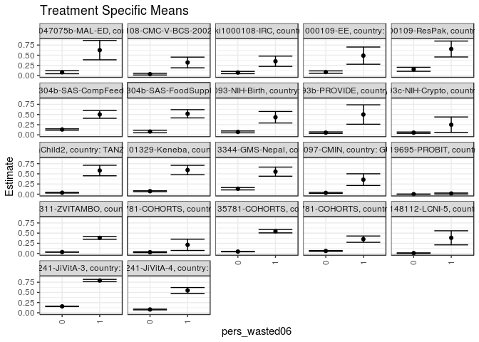

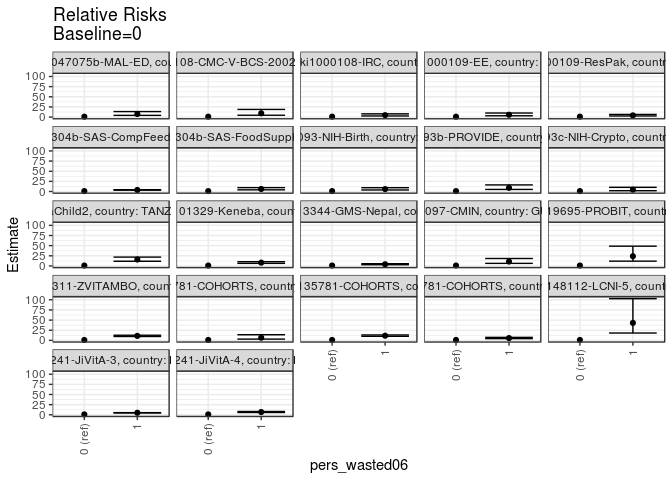

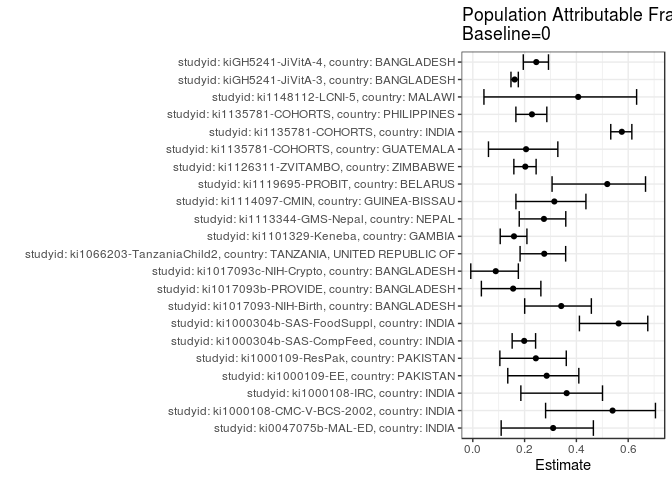

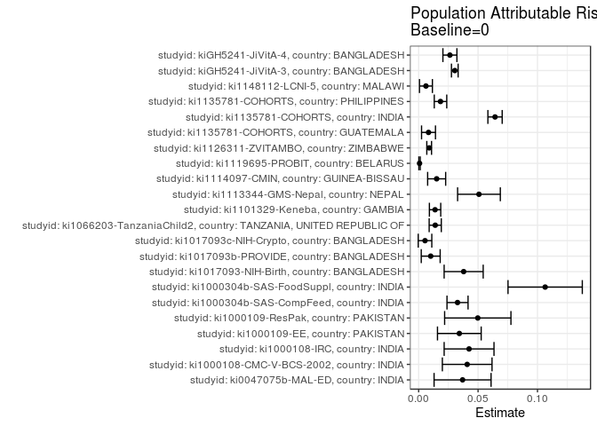

## Results Table

### Parameter: TSM

| studyid | country | intervention_level | baseline_level | estimate | ci_lower | ci_upper |
| --- | --- | --- | --- | --- | --- | --- |
| ki0047075b-MAL-ED | INDIA | 0 | NA | 0.0821918 | 0.0457380 | 0.1186455 |
| ki0047075b-MAL-ED | INDIA | 1 | NA | 0.6250000 | 0.3872778 | 0.8627222 |
| ki1000108-CMC-V-BCS-2002 | INDIA | 0 | NA | 0.0348333 | 0.0145968 | 0.0550698 |
| ki1000108-CMC-V-BCS-2002 | INDIA | 1 | NA | 0.3218880 | 0.1902081 | 0.4535680 |
| ki1000108-IRC | INDIA | 0 | NA | 0.0746441 | 0.0469608 | 0.1023274 |
| ki1000108-IRC | INDIA | 1 | NA | 0.3517106 | 0.2257236 | 0.4776977 |
| ki1000109-EE | PAKISTAN | 0 | NA | 0.0857712 | 0.0563460 | 0.1151965 |
| ki1000109-EE | PAKISTAN | 1 | NA | 0.4897554 | 0.2783526 | 0.7011582 |
| ki1000109-ResPak | PAKISTAN | 0 | NA | 0.1545894 | 0.1052342 | 0.2039446 |
| ki1000109-ResPak | PAKISTAN | 1 | NA | 0.6521739 | 0.4571027 | 0.8472451 |
| ki1000304b-SAS-CompFeed | INDIA | 0 | NA | 0.1320366 | 0.1155662 | 0.1485069 |
| ki1000304b-SAS-CompFeed | INDIA | 1 | NA | 0.5018650 | 0.4073634 | 0.5963665 |
| ki1000304b-SAS-FoodSuppl | INDIA | 0 | NA | 0.0825881 | 0.0516631 | 0.1135131 |
| ki1000304b-SAS-FoodSuppl | INDIA | 1 | NA | 0.5178799 | 0.4165397 | 0.6192201 |
| ki1017093-NIH-Birth | BANGLADESH | 0 | NA | 0.0730319 | 0.0499948 | 0.0960690 |
| ki1017093-NIH-Birth | BANGLADESH | 1 | NA | 0.4333896 | 0.2916994 | 0.5750798 |
| ki1017093b-PROVIDE | BANGLADESH | 0 | NA | 0.0549085 | 0.0366394 | 0.0731775 |
| ki1017093b-PROVIDE | BANGLADESH | 1 | NA | 0.5000000 | 0.2613176 | 0.7386824 |
| ki1017093c-NIH-Crypto | BANGLADESH | 0 | NA | 0.0549296 | 0.0381589 | 0.0717003 |
| ki1017093c-NIH-Crypto | BANGLADESH | 1 | NA | 0.2500000 | 0.0600972 | 0.4399028 |
| ki1066203-TanzaniaChild2 | TANZANIA, UNITED REPUBLIC OF | 0 | NA | 0.0366007 | 0.0282862 | 0.0449152 |
| ki1066203-TanzaniaChild2 | TANZANIA, UNITED REPUBLIC OF | 1 | NA | 0.5808018 | 0.4514559 | 0.7101478 |
| ki1101329-Keneba | GAMBIA | 0 | NA | 0.0729828 | 0.0621189 | 0.0838466 |
| ki1101329-Keneba | GAMBIA | 1 | NA | 0.5930816 | 0.4777332 | 0.7084301 |
| ki1113344-GMS-Nepal | NEPAL | 0 | NA | 0.1339938 | 0.1047141 | 0.1632734 |
| ki1113344-GMS-Nepal | NEPAL | 1 | NA | 0.5533780 | 0.4413481 | 0.6654078 |
| ki1114097-CMIN | GUINEA-BISSAU | 0 | NA | 0.0329452 | 0.0217374 | 0.0441531 |
| ki1114097-CMIN | GUINEA-BISSAU | 1 | NA | 0.3571643 | 0.2130745 | 0.5012541 |
| ki1119695-PROBIT | BELARUS | 0 | NA | 0.0006952 | 0.0001322 | 0.0012582 |
| ki1119695-PROBIT | BELARUS | 1 | NA | 0.0166432 | 0.0048003 | 0.0284861 |
| ki1126311-ZVITAMBO | ZIMBABWE | 0 | NA | 0.0347837 | 0.0310820 | 0.0384854 |
| ki1126311-ZVITAMBO | ZIMBABWE | 1 | NA | 0.3840060 | 0.3477394 | 0.4202726 |
| ki1135781-COHORTS | GUATEMALA | 0 | NA | 0.0320237 | 0.0208930 | 0.0431545 |
| ki1135781-COHORTS | GUATEMALA | 1 | NA | 0.2129605 | 0.0740850 | 0.3518361 |
| ki1135781-COHORTS | INDIA | 0 | NA | 0.0474441 | 0.0417290 | 0.0531591 |
| ki1135781-COHORTS | INDIA | 1 | NA | 0.5468064 | 0.5058920 | 0.5877207 |
| ki1135781-COHORTS | PHILIPPINES | 0 | NA | 0.0620998 | 0.0528293 | 0.0713702 |
| ki1135781-COHORTS | PHILIPPINES | 1 | NA | 0.3516264 | 0.2741496 | 0.4291032 |
| ki1148112-LCNI-5 | MALAWI | 0 | NA | 0.0089286 | 0.0022811 | 0.0155761 |
| ki1148112-LCNI-5 | MALAWI | 1 | NA | 0.3846154 | 0.2119598 | 0.5572710 |
| kiGH5241-JiVitA-3 | BANGLADESH | 0 | NA | 0.1576006 | 0.1513549 | 0.1638462 |
| kiGH5241-JiVitA-3 | BANGLADESH | 1 | NA | 0.7919335 | 0.7636786 | 0.8201884 |
| kiGH5241-JiVitA-4 | BANGLADESH | 0 | NA | 0.0809712 | 0.0716073 | 0.0903351 |
| kiGH5241-JiVitA-4 | BANGLADESH | 1 | NA | 0.5484830 | 0.4772283 | 0.6197377 |

### Parameter: E(Y)

| studyid | country | intervention_level | baseline_level | estimate | ci_lower | ci_upper |
| --- | --- | --- | --- | --- | --- | --- |
| ki0047075b-MAL-ED | INDIA | NA | NA | 0.1191489 | 0.0776405 | 0.1606574 |
| ki1000108-CMC-V-BCS-2002 | INDIA | NA | NA | 0.0756757 | 0.0486905 | 0.1026609 |
| ki1000108-IRC | INDIA | NA | NA | 0.1170732 | 0.0859146 | 0.1482317 |
| ki1000109-EE | PAKISTAN | NA | NA | 0.1200000 | 0.0870660 | 0.1529340 |
| ki1000109-ResPak | PAKISTAN | NA | NA | 0.2043478 | 0.1521230 | 0.2565727 |
| ki1000304b-SAS-CompFeed | INDIA | NA | NA | 0.1647399 | 0.1451050 | 0.1843747 |
| ki1000304b-SAS-FoodSuppl | INDIA | NA | NA | 0.1890547 | 0.1507312 | 0.2273783 |
| ki1017093-NIH-Birth | BANGLADESH | NA | NA | 0.1109057 | 0.0844206 | 0.1373909 |
| ki1017093b-PROVIDE | BANGLADESH | NA | NA | 0.0650407 | 0.0455353 | 0.0845460 |
| ki1017093c-NIH-Crypto | BANGLADESH | NA | NA | 0.0602740 | 0.0429977 | 0.0775502 |
| ki1066203-TanzaniaChild2 | TANZANIA, UNITED REPUBLIC OF | NA | NA | 0.0505451 | 0.0409848 | 0.0601054 |
| ki1101329-Keneba | GAMBIA | NA | NA | 0.0867841 | 0.0752007 | 0.0983676 |
| ki1113344-GMS-Nepal | NEPAL | NA | NA | 0.1847458 | 0.1534039 | 0.2160876 |
| ki1114097-CMIN | GUINEA-BISSAU | NA | NA | 0.0480864 | 0.0349437 | 0.0612290 |
| ki1119695-PROBIT | BELARUS | NA | NA | 0.0014461 | 0.0004206 | 0.0024716 |
| ki1126311-ZVITAMBO | ZIMBABWE | NA | NA | 0.0436257 | 0.0397395 | 0.0475120 |
| ki1135781-COHORTS | GUATEMALA | NA | NA | 0.0403147 | 0.0282199 | 0.0524094 |
| ki1135781-COHORTS | INDIA | NA | NA | 0.1117237 | 0.1042858 | 0.1191617 |
| ki1135781-COHORTS | PHILIPPINES | NA | NA | 0.0804843 | 0.0704205 | 0.0905481 |
| ki1148112-LCNI-5 | MALAWI | NA | NA | 0.0150565 | 0.0065967 | 0.0235162 |
| kiGH5241-JiVitA-3 | BANGLADESH | NA | NA | 0.1880070 | 0.1814627 | 0.1945512 |
| kiGH5241-JiVitA-4 | BANGLADESH | NA | NA | 0.1072724 | 0.0967392 | 0.1178055 |

### Parameter: RR

| studyid | country | intervention_level | baseline_level | estimate | ci_lower | ci_upper |
| --- | --- | --- | --- | --- | --- | --- |
| ki0047075b-MAL-ED | INDIA | 0 | 0 | 1.000000 | 1.000000 | 1.000000 |
| ki0047075b-MAL-ED | INDIA | 1 | 0 | 7.604167 | 4.239385 | 13.639560 |
| ki1000108-CMC-V-BCS-2002 | INDIA | 0 | 0 | 1.000000 | 1.000000 | 1.000000 |
| ki1000108-CMC-V-BCS-2002 | INDIA | 1 | 0 | 9.240823 | 4.540722 | 18.805999 |
| ki1000108-IRC | INDIA | 0 | 0 | 1.000000 | 1.000000 | 1.000000 |
| ki1000108-IRC | INDIA | 1 | 0 | 4.711832 | 2.808282 | 7.905672 |
| ki1000109-EE | PAKISTAN | 0 | 0 | 1.000000 | 1.000000 | 1.000000 |
| ki1000109-EE | PAKISTAN | 1 | 0 | 5.710019 | 3.283652 | 9.929284 |
| ki1000109-ResPak | PAKISTAN | 0 | 0 | 1.000000 | 1.000000 | 1.000000 |
| ki1000109-ResPak | PAKISTAN | 1 | 0 | 4.218750 | 2.723858 | 6.534061 |
| ki1000304b-SAS-CompFeed | INDIA | 0 | 0 | 1.000000 | 1.000000 | 1.000000 |
| ki1000304b-SAS-CompFeed | INDIA | 1 | 0 | 3.800955 | 3.293688 | 4.386346 |
| ki1000304b-SAS-FoodSuppl | INDIA | 0 | 0 | 1.000000 | 1.000000 | 1.000000 |
| ki1000304b-SAS-FoodSuppl | INDIA | 1 | 0 | 6.270636 | 4.106348 | 9.575631 |
| ki1017093-NIH-Birth | BANGLADESH | 0 | 0 | 1.000000 | 1.000000 | 1.000000 |
| ki1017093-NIH-Birth | BANGLADESH | 1 | 0 | 5.934250 | 3.765346 | 9.352482 |
| ki1017093b-PROVIDE | BANGLADESH | 0 | 0 | 1.000000 | 1.000000 | 1.000000 |
| ki1017093b-PROVIDE | BANGLADESH | 1 | 0 | 9.106061 | 5.088919 | 16.294295 |
| ki1017093c-NIH-Crypto | BANGLADESH | 0 | 0 | 1.000000 | 1.000000 | 1.000000 |
| ki1017093c-NIH-Crypto | BANGLADESH | 1 | 0 | 4.551282 | 2.007191 | 10.319981 |
| ki1066203-TanzaniaChild2 | TANZANIA, UNITED REPUBLIC OF | 0 | 0 | 1.000000 | 1.000000 | 1.000000 |
| ki1066203-TanzaniaChild2 | TANZANIA, UNITED REPUBLIC OF | 1 | 0 | 15.868600 | 11.544309 | 21.812692 |
| ki1101329-Keneba | GAMBIA | 0 | 0 | 1.000000 | 1.000000 | 1.000000 |
| ki1101329-Keneba | GAMBIA | 1 | 0 | 8.126326 | 6.360930 | 10.381684 |
| ki1113344-GMS-Nepal | NEPAL | 0 | 0 | 1.000000 | 1.000000 | 1.000000 |
| ki1113344-GMS-Nepal | NEPAL | 1 | 0 | 4.129879 | 3.070737 | 5.554334 |
| ki1114097-CMIN | GUINEA-BISSAU | 0 | 0 | 1.000000 | 1.000000 | 1.000000 |
| ki1114097-CMIN | GUINEA-BISSAU | 1 | 0 | 10.841155 | 6.402348 | 18.357428 |
| ki1119695-PROBIT | BELARUS | 0 | 0 | 1.000000 | 1.000000 | 1.000000 |
| ki1119695-PROBIT | BELARUS | 1 | 0 | 23.939633 | 11.763517 | 48.718935 |
| ki1126311-ZVITAMBO | ZIMBABWE | 0 | 0 | 1.000000 | 1.000000 | 1.000000 |
| ki1126311-ZVITAMBO | ZIMBABWE | 1 | 0 | 11.039823 | 9.576992 | 12.726092 |
| ki1135781-COHORTS | GUATEMALA | 0 | 0 | 1.000000 | 1.000000 | 1.000000 |
| ki1135781-COHORTS | GUATEMALA | 1 | 0 | 6.650089 | 3.186535 | 13.878298 |
| ki1135781-COHORTS | INDIA | 0 | 0 | 1.000000 | 1.000000 | 1.000000 |
| ki1135781-COHORTS | INDIA | 1 | 0 | 11.525289 | 10.006489 | 13.274615 |
| ki1135781-COHORTS | PHILIPPINES | 0 | 0 | 1.000000 | 1.000000 | 1.000000 |
| ki1135781-COHORTS | PHILIPPINES | 1 | 0 | 5.662282 | 4.344975 | 7.378969 |
| ki1148112-LCNI-5 | MALAWI | 0 | 0 | 1.000000 | 1.000000 | 1.000000 |
| ki1148112-LCNI-5 | MALAWI | 1 | 0 | 43.076923 | 18.058272 | 102.757410 |
| kiGH5241-JiVitA-3 | BANGLADESH | 0 | 0 | 1.000000 | 1.000000 | 1.000000 |
| kiGH5241-JiVitA-3 | BANGLADESH | 1 | 0 | 5.024940 | 4.772597 | 5.290625 |
| kiGH5241-JiVitA-4 | BANGLADESH | 0 | 0 | 1.000000 | 1.000000 | 1.000000 |
| kiGH5241-JiVitA-4 | BANGLADESH | 1 | 0 | 6.773803 | 5.692671 | 8.060259 |

### Parameter: PAR

| studyid | country | intervention_level | baseline_level | estimate | ci_lower | ci_upper |
| --- | --- | --- | --- | --- | --- | --- |
| ki0047075b-MAL-ED | INDIA | 0 | NA | 0.0369572 | 0.0129774 | 0.0609369 |
| ki1000108-CMC-V-BCS-2002 | INDIA | 0 | NA | 0.0408424 | 0.0199422 | 0.0617426 |
| ki1000108-IRC | INDIA | 0 | NA | 0.0424290 | 0.0214553 | 0.0634027 |
| ki1000109-EE | PAKISTAN | 0 | NA | 0.0342288 | 0.0158370 | 0.0526205 |
| ki1000109-ResPak | PAKISTAN | 0 | NA | 0.0497585 | 0.0218535 | 0.0776634 |
| ki1000304b-SAS-CompFeed | INDIA | 0 | NA | 0.0327033 | 0.0238373 | 0.0415693 |
| ki1000304b-SAS-FoodSuppl | INDIA | 0 | NA | 0.1064666 | 0.0752065 | 0.1377267 |
| ki1017093-NIH-Birth | BANGLADESH | 0 | NA | 0.0378738 | 0.0214411 | 0.0543065 |
| ki1017093b-PROVIDE | BANGLADESH | 0 | NA | 0.0101322 | 0.0021706 | 0.0180938 |
| ki1017093c-NIH-Crypto | BANGLADESH | 0 | NA | 0.0053444 | -0.0003673 | 0.0110561 |
| ki1066203-TanzaniaChild2 | TANZANIA, UNITED REPUBLIC OF | 0 | NA | 0.0139444 | 0.0088406 | 0.0190482 |
| ki1101329-Keneba | GAMBIA | 0 | NA | 0.0138014 | 0.0090282 | 0.0185745 |
| ki1113344-GMS-Nepal | NEPAL | 0 | NA | 0.0507520 | 0.0327771 | 0.0687269 |
| ki1114097-CMIN | GUINEA-BISSAU | 0 | NA | 0.0151411 | 0.0075580 | 0.0227243 |
| ki1119695-PROBIT | BELARUS | 0 | NA | 0.0007509 | 0.0001686 | 0.0013333 |
| ki1126311-ZVITAMBO | ZIMBABWE | 0 | NA | 0.0088420 | 0.0068471 | 0.0108370 |
| ki1135781-COHORTS | GUATEMALA | 0 | NA | 0.0082909 | 0.0024306 | 0.0141513 |
| ki1135781-COHORTS | INDIA | 0 | NA | 0.0642797 | 0.0582661 | 0.0702933 |
| ki1135781-COHORTS | PHILIPPINES | 0 | NA | 0.0183846 | 0.0131328 | 0.0236364 |
| ki1148112-LCNI-5 | MALAWI | 0 | NA | 0.0061279 | 0.0006884 | 0.0115674 |
| kiGH5241-JiVitA-3 | BANGLADESH | 0 | NA | 0.0304064 | 0.0276008 | 0.0332119 |
| kiGH5241-JiVitA-4 | BANGLADESH | 0 | NA | 0.0263012 | 0.0204069 | 0.0321955 |

### Parameter: PAF

| studyid | country | intervention_level | baseline_level | estimate | ci_lower | ci_upper |
| --- | --- | --- | --- | --- | --- | --- |
| ki0047075b-MAL-ED | INDIA | 0 | NA | 0.3101761 | 0.1095701 | 0.4655873 |
| ki1000108-CMC-V-BCS-2002 | INDIA | 0 | NA | 0.5397033 | 0.2811088 | 0.7052780 |
| ki1000108-IRC | INDIA | 0 | NA | 0.3624146 | 0.1855765 | 0.5008553 |
| ki1000109-EE | PAKISTAN | 0 | NA | 0.2852396 | 0.1350490 | 0.4093511 |
| ki1000109-ResPak | PAKISTAN | 0 | NA | 0.2434988 | 0.1045154 | 0.3609113 |
| ki1000304b-SAS-CompFeed | INDIA | 0 | NA | 0.1985149 | 0.1519871 | 0.2424899 |
| ki1000304b-SAS-FoodSuppl | INDIA | 0 | NA | 0.5631524 | 0.4117232 | 0.6756020 |
| ki1017093-NIH-Birth | BANGLADESH | 0 | NA | 0.3414957 | 0.2002914 | 0.4577676 |
| ki1017093b-PROVIDE | BANGLADESH | 0 | NA | 0.1557820 | 0.0331417 | 0.2628662 |
| ki1017093c-NIH-Crypto | BANGLADESH | 0 | NA | 0.0886684 | -0.0078075 | 0.1759087 |
| ki1066203-TanzaniaChild2 | TANZANIA, UNITED REPUBLIC OF | 0 | NA | 0.2758803 | 0.1825845 | 0.3585278 |
| ki1101329-Keneba | GAMBIA | 0 | NA | 0.1590312 | 0.1059095 | 0.2089967 |
| ki1113344-GMS-Nepal | NEPAL | 0 | NA | 0.2747127 | 0.1793212 | 0.3590165 |
| ki1114097-CMIN | GUINEA-BISSAU | 0 | NA | 0.3148737 | 0.1665418 | 0.4368068 |
| ki1119695-PROBIT | BELARUS | 0 | NA | 0.5192578 | 0.3060750 | 0.6669481 |
| ki1126311-ZVITAMBO | ZIMBABWE | 0 | NA | 0.2026793 | 0.1585578 | 0.2444872 |
| ki1135781-COHORTS | GUATEMALA | 0 | NA | 0.2056558 | 0.0605616 | 0.3283405 |
| ki1135781-COHORTS | INDIA | 0 | NA | 0.5753449 | 0.5326789 | 0.6141156 |
| ki1135781-COHORTS | PHILIPPINES | 0 | NA | 0.2284241 | 0.1663891 | 0.2858426 |
| ki1148112-LCNI-5 | MALAWI | 0 | NA | 0.4069940 | 0.0430324 | 0.6325309 |
| kiGH5241-JiVitA-3 | BANGLADESH | 0 | NA | 0.1617300 | 0.1474362 | 0.1757843 |
| kiGH5241-JiVitA-4 | BANGLADESH | 0 | NA | 0.2451812 | 0.1949727 | 0.2922583 |